# Spinning

Clifton Anderson

## Results from spinning whole blood on ruffled disks

Here is a table of how many replicates have been done on each disk. The columns tell if the hematocrit of the whole blood was measured or not.

```
##
##                       FALSE TRUE
##   16b                     0    9
##   20.035_8x3_1.25x7mm     0    6
##   20.05_16x3              0   39
##   20.05_16x3_3mL          1   10
##   20.05_16x3_5mL          0    9
##   20.05_16x3_peo          0   12
##   20.05_8x3               0    6
##   20.05_8x3_0.75x9mm      0    4
##   20.05_8x3_1.25x7mm      0   10
##   20.05_8x3_1.25x9mm      0    4
##   20.05_8x3long           0    5
##   base                    0   13
##   base_2mm_weir           0    6
##   matte_12H               1    2
##   matte_20.05             1    4
##   matte_20.05_16b         0    2
##   matte_70.05             4    4
##   matte_70.05_16b         0   12
##   Moat                    0    4
##   Moat2                   0    4
```

## RBC and plasma recovery

I have calculated the plasma recovery and red cell recovery using the following steps. I need to calculate the volume of the flowdown. If I chose not to dilute my blood with PBS, I would have a binary mixture of plasma and RBCs. Since I’m adding PBS though, I have a ternary mixture and cannot use the reference plasma density of 1024 $kg/m^3$. Because I can only obtain the volume fraction of red blood cells in the flowdown, I have an extra degree of freedom. To remove this, I will simplify this system back to binary by making a composite (i.e. solution) density between PBS and plasma as a function of their volumes.
$$m_{solution} = \rho_{PBS}V_{PBS} + \rho_{plasma}(1-HCT_{whole\;blood})V_{whole\;blood}$$
$$\rho_{solution} = \frac{m_{solution}}{V_{whole\;blood}(1-HCT_{whole\;blood})+V_{PBS}}$$
The volume fraction of plasma in solution is
$$\nu_{plasma} = \frac{V_{whole\;blood}(1-HCT_{whole\;blood})}{V_{PBS}+V_{whole\;blood}(1-HCT_{whole\;blood})}$$
The mass of the flowdown is measured directly. It can be represented as a ternary mixture $\sum{\rho_{i}V_{i}}, \;\;i=WB, plasma, PBS$ or as a binary mixture using the $\rho_{solution}$ just calculated. This latter approach will be used for the remainder of the derivation.
$$m_{flowdown} = \rho_{solution}V_{solution}+\rho_{RBC}V_{RBC}$$
Moving to the next step require the intermediate values: $V_{solution} = V_{flowdown}(1-HCT_{flowdown})$ and $V_{RBC} = V_{flowdown}HCT_{flowdown}$. Substituting these values into the equation above yields:

$$m_{flowdown} = V_{flowdown}[\rho_{solution}(1-HCT_{flowdown})+\rho_{RBC}HCT_{flowdown}]$$

A simple rearrangement gives $V_{flowdown}$ in the following expression:

$$V_{flowdown} = \frac{m_{flowdown}}{\rho_{solution}(1-HCT_{plasma})+\rho_{RBC}HCT_{flowdown}}$$
Now the Plasma and RBC recoveries can be calculated. The plasma recovery (simplified) is given by:
$$Plasma \; Recovery \;(\%) = \frac{V_{flowdown}(1-HCT_{flowdown})}{V_{PBS} + V_{whole\;blood}(1-HCT_{whole \;blood})}*100$$

$$RBC \; Recovery \;(\%) = \frac{V_{flowdown}HCT_{flowdown}}{V_{whole\;blood}HCT_{whole\;blood}}*100$$
Need to 3x check the plasma recovery

```r
Temp = 23 #C
rho_PBS <- -5.2037e-6*Temp^2 - 8.1463e-6*Temp + 1.0097
# I got this correlation from
# (http://www.sciencedirect.com/science/article/pii/S003991400400373X)

spins$VolFracPlasma  <- with(spins,{VolWB*(1-HCT)/(VolWB*(1-HCT) + VolPBS)})
spins$RhoSolution    <- with(spins,{(rho_PBS*VolPBS + 1.024*(1-HCT)*VolWB)/(VolPBS + (1-HCT)*VolWB)})
spins$VFlowdown      <- with(spins,{gplas_tot/(RhoSolution*(1-HCT_plas)+1.093*HCT_plas)})
spins[is.na(spins$HCT_plas),]$VFlowdown <- spins[is.na(spins$HCT_plas),]$gplas_tot/1.024
# Some disks have missing HCT_plasma values. For these disks, I approximate the density of the
# flowdown as that of pure plasma. This lets me keep these data with little introduced error.

spins$RBCRecovery    <- with(spins,{VFlowdown*HCT_plas/(VolWB*HCT)*100})
spins$PlasmaRecovery <- with(spins,{VFlowdown*(1-HCT_plas)/(VolPBS+VolWB*(1-HCT)-0.6)*100})
```

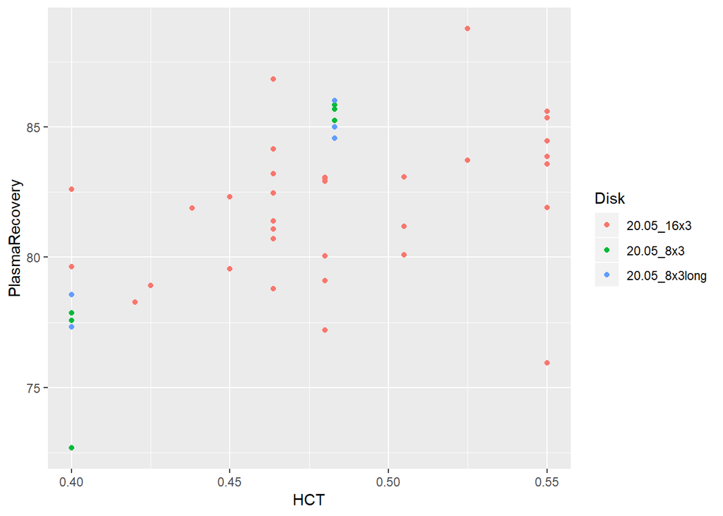

```r
Nruffles <- subset(spins,Ruffles==TRUE &
                     HCT<=0.55 &
                     Trough.Volume == 4 &
                     !grepl('peo',spins$Disk) &
                     !grepl('mm',spins$Disk))

ggplot(Nruffles,aes(HCT,PlasmaRecovery,color=Disk))+geom_point()
```

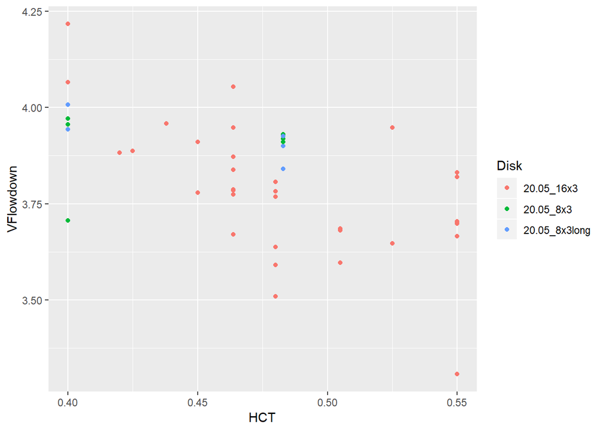

```r
ggplot(Nruffles,aes(HCT,VFlowdown,color=Disk))+geom_point()
```

```r
spins %>%
  group_by(Glossy,Disk) %>%
  drop_na(VFlowdown) %>%
  filter(VFlowdown>2) %>% # Remove one outlier from matte_70.05
  summarise(nspins = n(),
            Vol.mean = mean(VFlowdown),
            Vol.var = sd(VFlowdown)^2,
            SSWDisk = sum((VFlowdown-Vol.mean)^2)) %>%
  summarise(nglossy = sum(nspins),
            SSWGlossy = sum(SSWDisk)/nglossy)
```

```
## # A tibble: 2 x 3
##   Glossy nglossy SSWGlossy
##   <lgl>    <int>     <dbl>
## 1 FALSE       29    0.201
## 2 TRUE       140    0.0333
```

```r
GM <- 0.02256/0.20121 # ratio of within-Disk nested within glossy MSE
F975 <- qf(0.975,df1=128,df2=29)
F975
```

```
## [1] 1.881356
```

```r
sqrt(GM/F975)
```

```
## [1] 0.2441233
```

```r
sqrt(GM)
```

```
## [1] 0.3348457
```

```r
sqrt(GM*F975)
```

```
## [1] 0.4592829
```

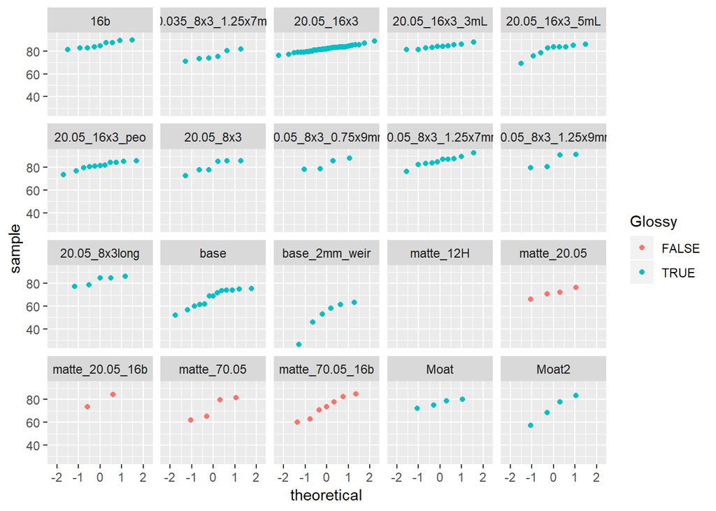

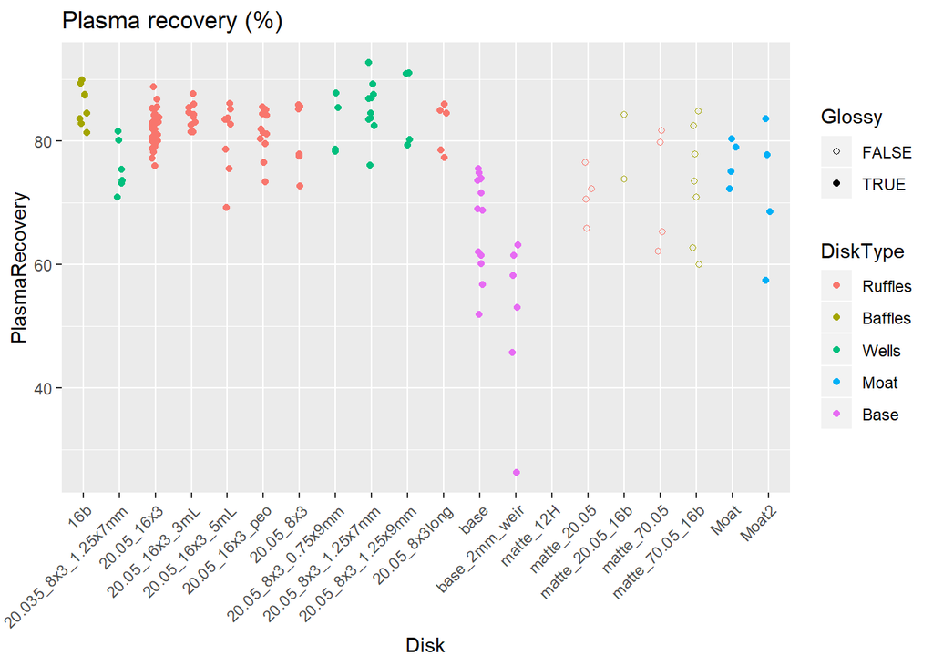

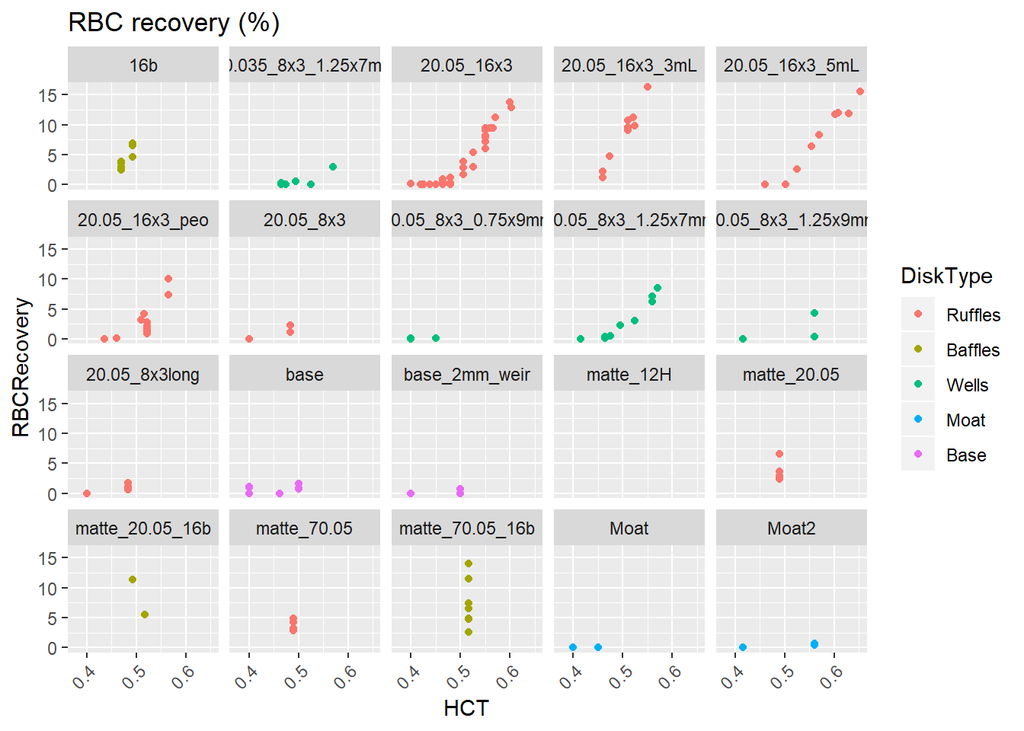

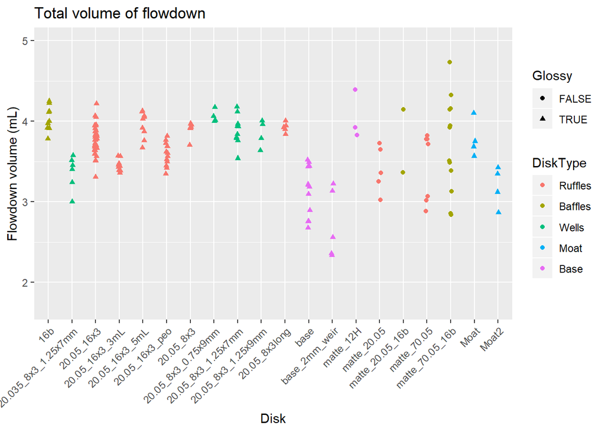

```r
ggplot(spins,aes(sample=PlasmaRecovery,color=Glossy))+stat_qq()+facet_wrap(~Disk)
```

The reason most of the glossy disks have higher plasma recovery is because the flowdown is more predictable. With the matte ones, the same maximum flowdown is possible, but the rough surface presents an energy barrier, so a column of liquid with a given force has a lower chance of beating the threshold.

Polymer coating did not affect rate of RBC recovery

Summary by disk

| DiskType | Disk | n | Flowdown | ci_Flowdown | npr | PR | ci_Plasma | RR | ci_RBC |
| --- | --- | --- | --- | --- | --- | --- | --- | --- | --- |
| Base | base | 13 | 3.225415 | 0.1869986 | 13 | 67.20215 | 4.7345728 | 0.4113957 | 0.3434161 |
| Base | base_2mm_weir | 6 | 2.509100 | 0.7969731 | 6 | 51.33513 | 14.4801162 | 0.1123583 | 0.2888263 |
| Wells | 20.05_8x3_1.25x9mm | 4 | 3.926025 | 0.2750467 | 4 | 85.39351 | 10.3146916 | 1.1805646 | 3.3747564 |
| Wells | 20.05_8x3_1.25x7mm | 10 | 3.968450 | 0.1339770 | 10 | 85.37944 | 3.1955991 | 2.8284747 | 2.3499595 |
| Wells | 20.05_8x3_0.75x9mm | 4 | 4.141175 | 0.1261964 | 4 | 82.56872 | 7.5796616 | 0.1010885 | 0.1076457 |
| Wells | 20.035_8x3_1.25x7mm | 6 | 3.429667 | 0.2232337 | 6 | 75.84165 | 4.4137921 | 0.6570203 | 1.2275234 |
| Baffles | 16b | 9 | 4.121322 | 0.1212234 | 9 | 85.51315 | 2.4034578 | 4.0614360 | 1.2958753 |
| Baffles | matte_20.05_16b | 2 | 3.847300 | 5.1663428 | 2 | 79.05880 | 66.3234987 | 8.5006048 | 37.1698831 |
| Baffles | matte_70.05_16b | 12 | 3.793283 | 0.3908061 | 7 | 73.21035 | 8.7412471 | 7.3876135 | 3.7476520 |
| Ruffles | 20.05_16x3_3mL | 11 | 3.531709 | 0.0529149 | 10 | 84.09216 | 1.4198721 | 8.4062605 | 3.2355462 |
| Ruffles | 20.05_8x3long | 5 | 4.000240 | 0.0768128 | 5 | 82.29288 | 5.0015603 | 0.6918701 | 0.9356081 |
| Ruffles | 20.05_16x3 | 39 | 3.844277 | 0.0545270 | 38 | 82.01973 | 0.8701443 | 3.5623131 | 1.4557440 |
| Ruffles | 20.05_16x3_peo | 12 | 3.662475 | 0.0946995 | 11 | 81.23244 | 2.5123527 | 3.0668047 | 2.0832680 |
| Ruffles | 20.05_16x3_5mL | 9 | 4.056611 | 0.1363134 | 9 | 80.93165 | 4.2173033 | 7.6240610 | 4.3688135 |
| Ruffles | 20.05_8x3 | 6 | 3.975733 | 0.1039989 | 6 | 80.81170 | 5.8220546 | 0.7734622 | 0.9953567 |
| Ruffles | matte_70.05 | 8 | 3.291698 | 0.6273662 | 4 | 72.24556 | 15.8365374 | 3.7926659 | 1.5471416 |
| Ruffles | matte_20.05 | 5 | 3.478140 | 0.3708800 | 4 | 71.31635 | 7.0555877 | 3.8860099 | 2.9463945 |

[output not shown]

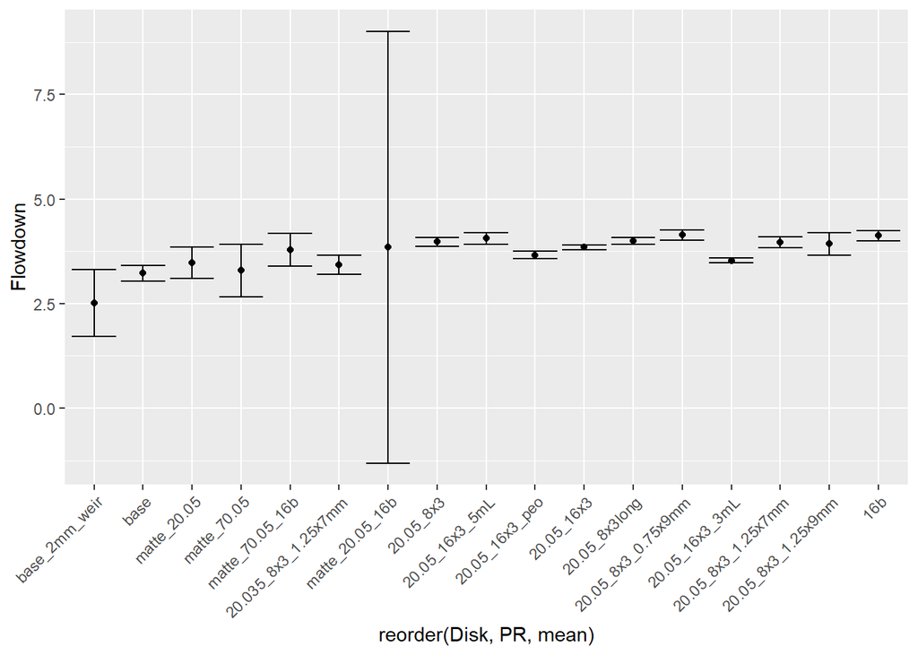

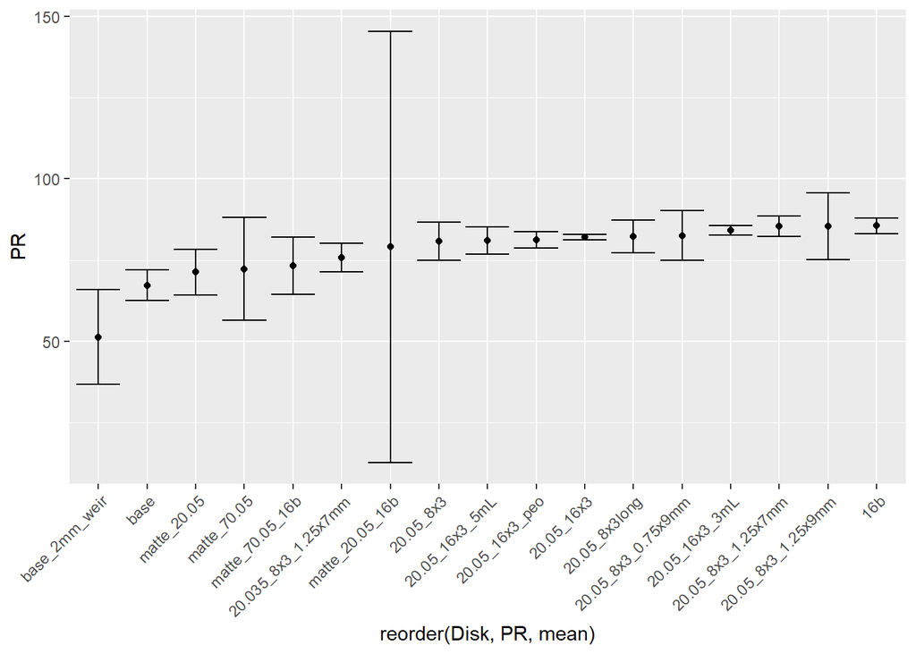

```r
features <- spins %>% dplyr::select(Disk,HCT,gplas_tot,RBCRecovery,PlasmaRecovery,Baffles,Glossy,Ruffles,Wells,LongWeir,DiskType)
str(features)
```

```
## 'data.frame':    172 obs. of  11 variables:
##  $ Disk          : Factor w/ 20 levels "16b","20.035_8x3_1.25x7mm",..: 14 14 18 18 18 18 15 17 17 17 ...
##  $ HCT           : num  0.48 0.48 0.48 0.48 0.48 0.48 0.49 0.49 0.49 0.49 ...
##  $ gplas_tot     : num  4.02 3.92 4.43 4.85 3.57 ...
##  $ RBCRecovery   : num  NaN NaN NaN NaN NaN ...
##  $ PlasmaRecovery: num  NaN NaN NaN NaN NaN ...
##  $ Baffles       : logi  FALSE FALSE TRUE TRUE TRUE TRUE ...
##  $ Glossy        : logi  FALSE FALSE FALSE FALSE FALSE FALSE ...
##  $ Ruffles       : logi  FALSE FALSE FALSE FALSE FALSE FALSE ...
##  $ Wells         : logi  FALSE FALSE FALSE FALSE FALSE FALSE ...
##  $ LongWeir      : logi  TRUE TRUE TRUE TRUE TRUE TRUE ...
##  $ DiskType      : Factor w/ 5 levels "Ruffles","Baffles",..: 5 5 2 2 2 2 1 1 1 1 ...
```

```r
features.lm <- lm(PlasmaRecovery ~ Baffles*Glossy*Ruffles*Wells*LongWeir,data=features);summary(features.lm)
```

```
##
## Call:
## lm(formula = PlasmaRecovery ~ Baffles * Glossy * Ruffles * Wells *
##     LongWeir, data = features)
##
## Residuals:
##     Min      1Q  Median      3Q     Max
## -38.161  -3.085   0.659   3.522  19.225
##
## Coefficients: (25 not defined because of singularities)
##                                                           Estimate
## (Intercept)                                                74.5397
## BafflesTRUE                                                 2.7291
## GlossyTRUE                                                 -7.3376
## RufflesTRUE                                                17.5306
## WellsTRUE                                                   0.5549
## LongWeirTRUE                                               -2.7588
## BafflesTRUE:GlossyTRUE                                     15.5820
## BafflesTRUE:RufflesTRUE                                         NA
## GlossyTRUE:RufflesTRUE                                          NA
## BafflesTRUE:WellsTRUE                                           NA
## GlossyTRUE:WellsTRUE                                            NA
## RufflesTRUE:WellsTRUE                                           NA
## BafflesTRUE:LongWeirTRUE                                        NA
## GlossyTRUE:LongWeirTRUE                                         NA
## RufflesTRUE:LongWeirTRUE                                        NA
## WellsTRUE:LongWeirTRUE                                          NA
## BafflesTRUE:GlossyTRUE:RufflesTRUE                              NA
## BafflesTRUE:GlossyTRUE:WellsTRUE                                NA
## BafflesTRUE:RufflesTRUE:WellsTRUE                               NA
## GlossyTRUE:RufflesTRUE:WellsTRUE                                NA
## BafflesTRUE:GlossyTRUE:LongWeirTRUE                             NA
## BafflesTRUE:RufflesTRUE:LongWeirTRUE                            NA
## GlossyTRUE:RufflesTRUE:LongWeirTRUE                             NA
## BafflesTRUE:WellsTRUE:LongWeirTRUE                              NA
## GlossyTRUE:WellsTRUE:LongWeirTRUE                               NA
## RufflesTRUE:WellsTRUE:LongWeirTRUE                              NA
## BafflesTRUE:GlossyTRUE:RufflesTRUE:WellsTRUE                    NA
## BafflesTRUE:GlossyTRUE:RufflesTRUE:LongWeirTRUE                 NA
## BafflesTRUE:GlossyTRUE:WellsTRUE:LongWeirTRUE                   NA
```

[output cut: 94 more lines]

```
## GlossyTRUE:WellsTRUE:LongWeirTRUE
## RufflesTRUE:WellsTRUE:LongWeirTRUE
## BafflesTRUE:GlossyTRUE:RufflesTRUE:WellsTRUE
## BafflesTRUE:GlossyTRUE:RufflesTRUE:LongWeirTRUE
## BafflesTRUE:GlossyTRUE:WellsTRUE:LongWeirTRUE
## BafflesTRUE:RufflesTRUE:WellsTRUE:LongWeirTRUE
## GlossyTRUE:RufflesTRUE:WellsTRUE:LongWeirTRUE
## BafflesTRUE:GlossyTRUE:RufflesTRUE:WellsTRUE:LongWeirTRUE
## ---
## Signif. codes:  0 '***' 0.001 '**' 0.01 '*' 0.05 '.' 0.1 ' ' 1
##
## Residual standard error: 6.787 on 149 degrees of freedom
##   (16 observations deleted due to missingness)
## Multiple R-squared:  0.4946, Adjusted R-squared:  0.4742
## F-statistic:  24.3 on 6 and 149 DF,  p-value: < 2.2e-16
```

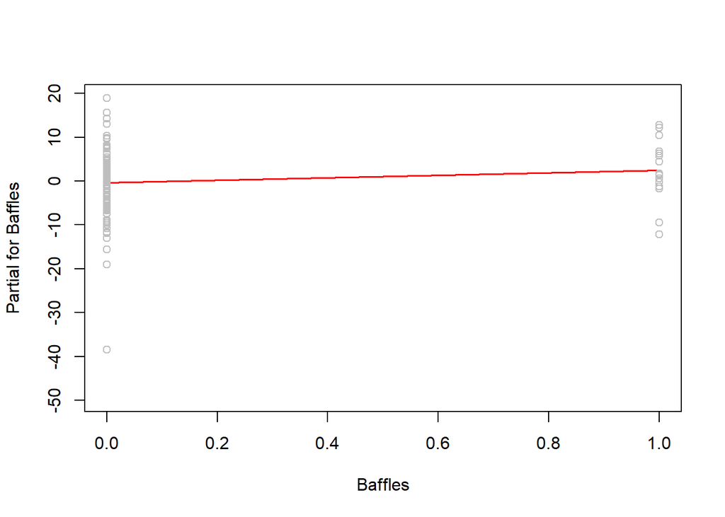

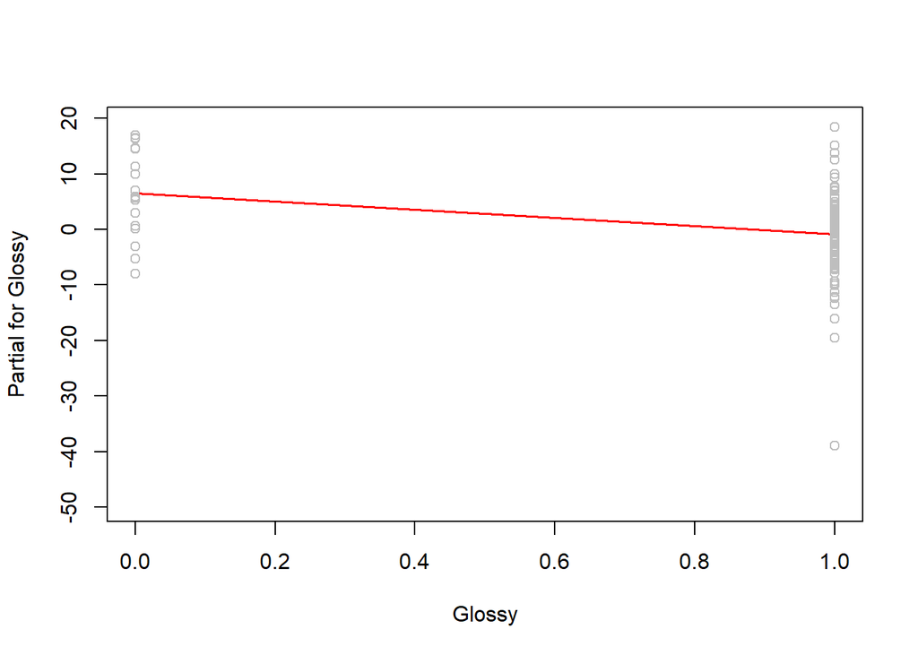

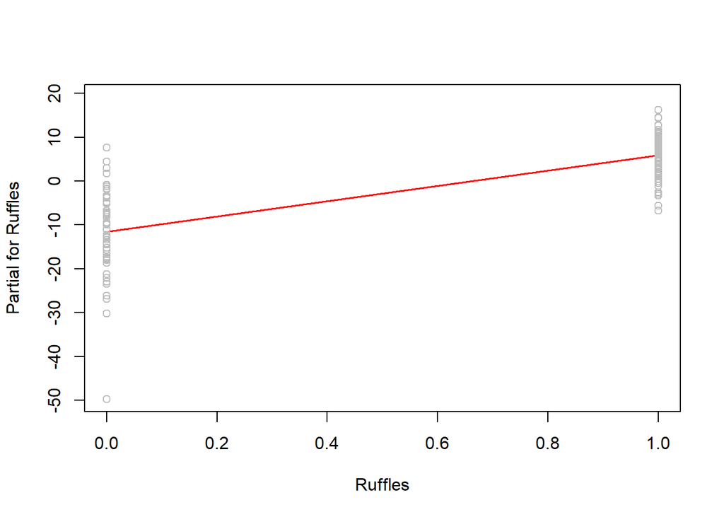

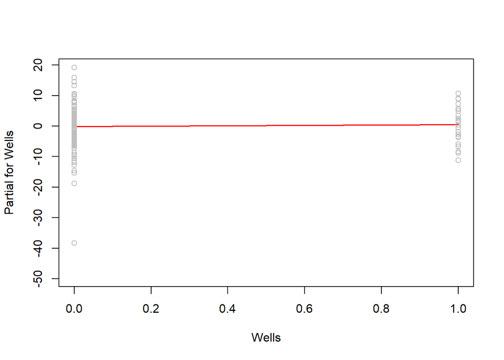

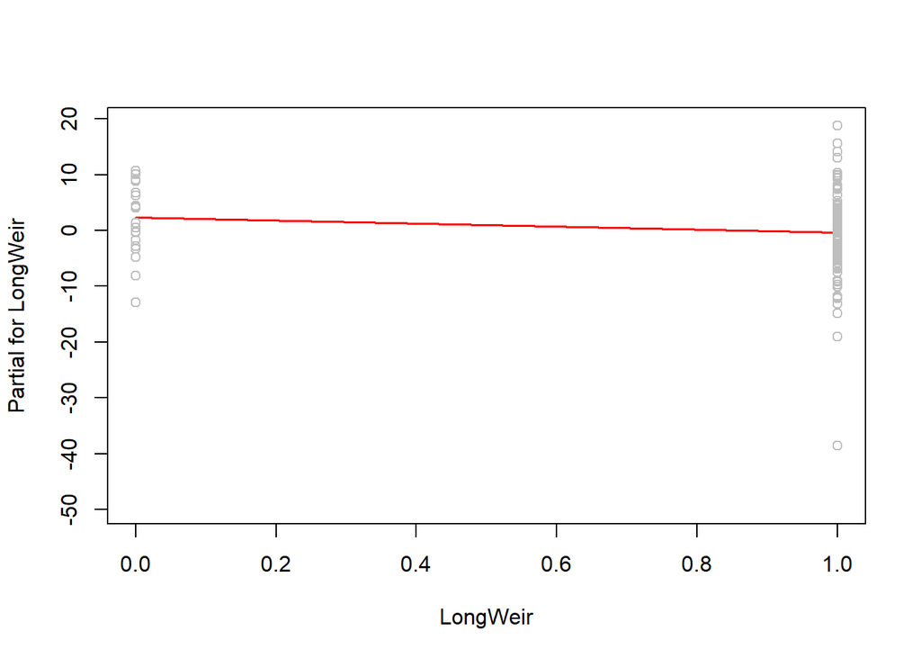

```r
termplot(features.lm,partial.resid = TRUE)
```

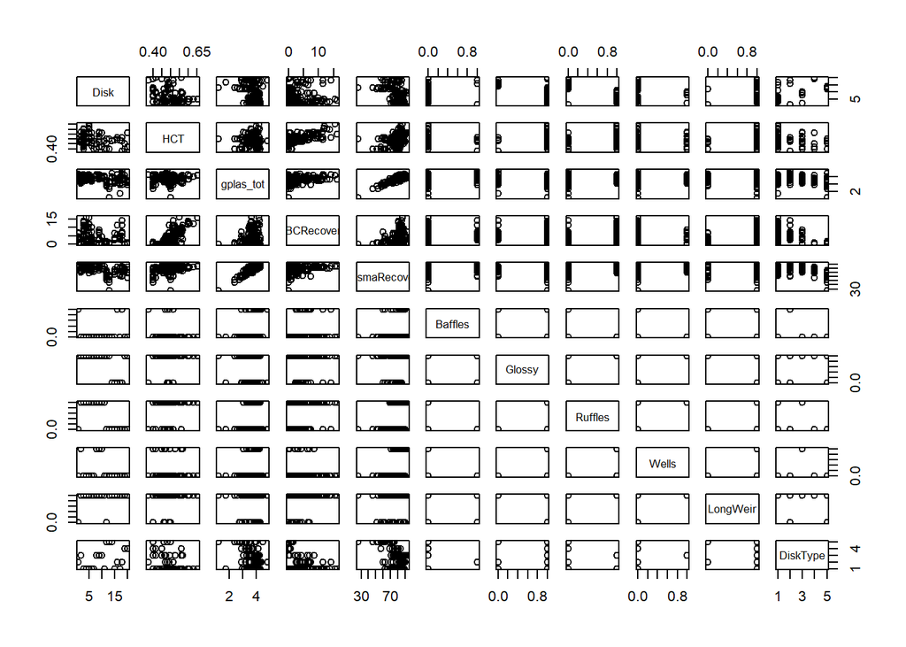

```r
pairs(features)
```

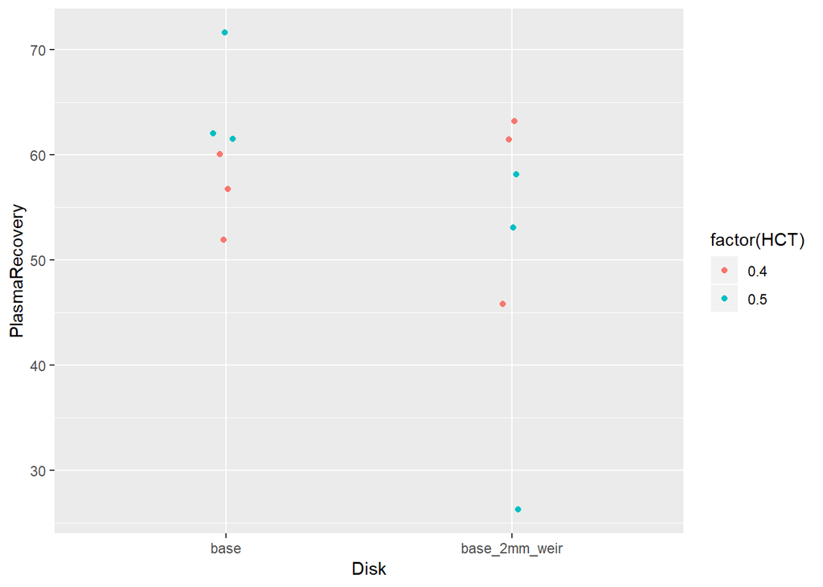

```r
weir <- filter(spins, Date=='2019-6-20') #Disk %in% c('base','base_2mm_weir'))
ggplot(weir,aes(Disk,PlasmaRecovery,color=factor(HCT)))+geom_jitter(width=0.05)
```

```r
temp <- spins %>% filter(!is.na(PlasmaRecovery),
                         # Disk %in% c('20.05_16x3','20.05_8x3_1.25x7mm'),
                         Glossy==TRUE,
                         # !DiskType %in% c('Base','Moat'),
                         # !Disk %in% c('20.035_8x3_1.25x7mm','20.05_16x3_3mL','20.05_16x3_5mL')
                         ) %>%
                  droplevels()

DiskType.aov <- aov(PlasmaRecovery~DiskType,data=temp);summary(DiskType.aov)
```

```
##              Df Sum Sq Mean Sq F value Pr(>F)
## DiskType      4   6923    1731   45.55 <2e-16 ***
## Residuals   134   5091      38
## ---
## Signif. codes:  0 '***' 0.001 '**' 0.01 '*' 0.05 '.' 0.1 ' ' 1
```

```r
TukeyHSD(DiskType.aov)
```

```
##   Tukey multiple comparisons of means
##     95% family-wise confidence level
##
## Fit: aov(formula = PlasmaRecovery ~ DiskType, data = temp)
##
## $DiskType
##                        diff        lwr        upr     p adj
## Baffles-Ruffles   3.5391346  -2.457467   9.535736 0.4797268
## Wells-Ruffles     0.5548673  -3.417945   4.527680 0.9952357
## Moat-Ruffles     -7.6994206 -14.023535  -1.375306 0.0086667
## Base-Ruffles    -19.7825094 -24.137842 -15.427177 0.0000000
## Wells-Baffles    -2.9842672  -9.646637   3.678103 0.7287931
## Moat-Baffles    -11.2385552 -19.520968  -2.956143 0.0023809
## Base-Baffles    -23.3216439 -30.218952 -16.424336 0.0000000
## Moat-Wells       -8.2542880 -15.212906  -1.295670 0.0113816
## Base-Wells      -20.3373767 -25.571578 -15.103175 0.0000000
## Base-Moat       -12.0830887 -19.266963  -4.899214 0.0000759
```

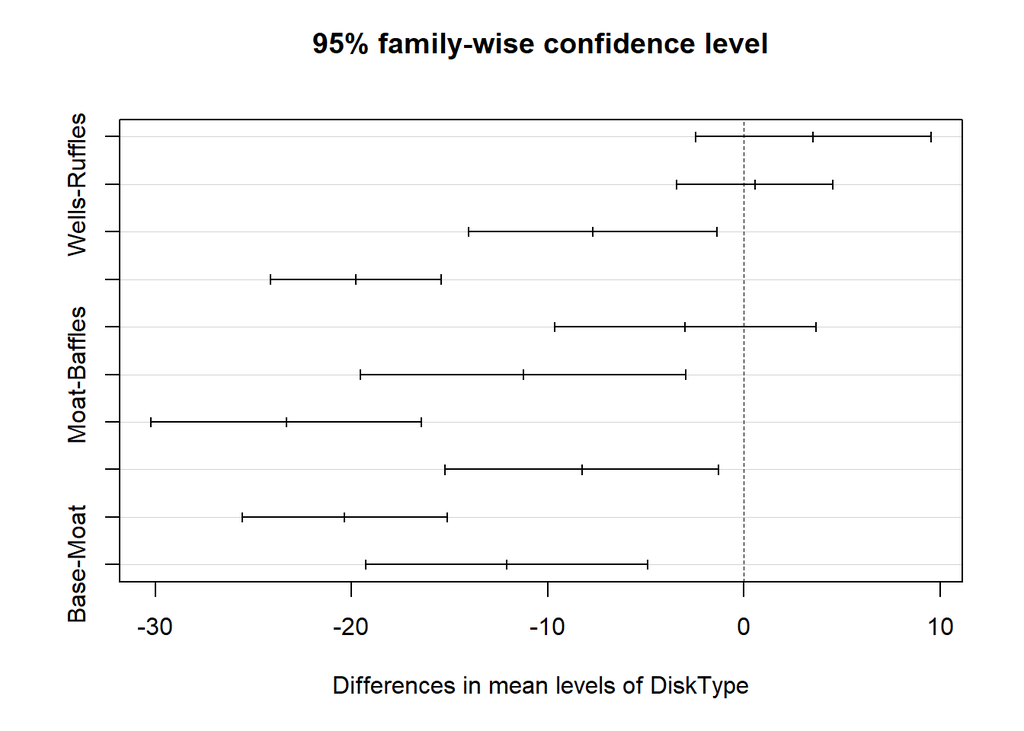

```r
plot(TukeyHSD(DiskType.aov))
```

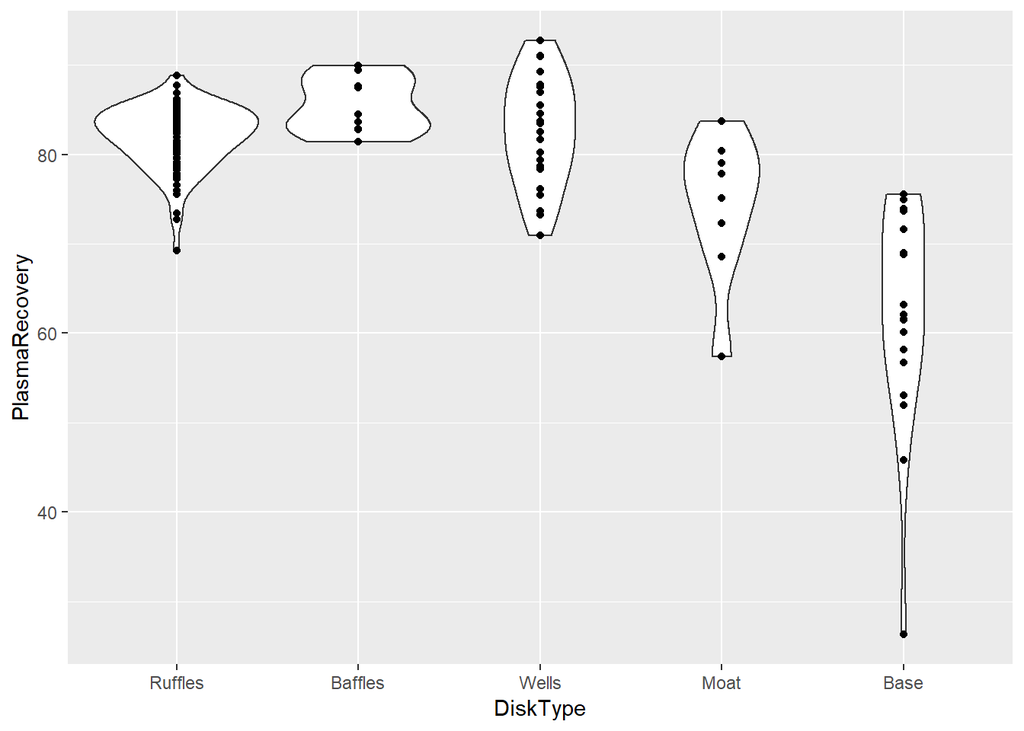

```r
# model assumption checking - normality and homoscedascity
ggplot(temp,aes(DiskType,PlasmaRecovery))+geom_violin()+geom_point()
```

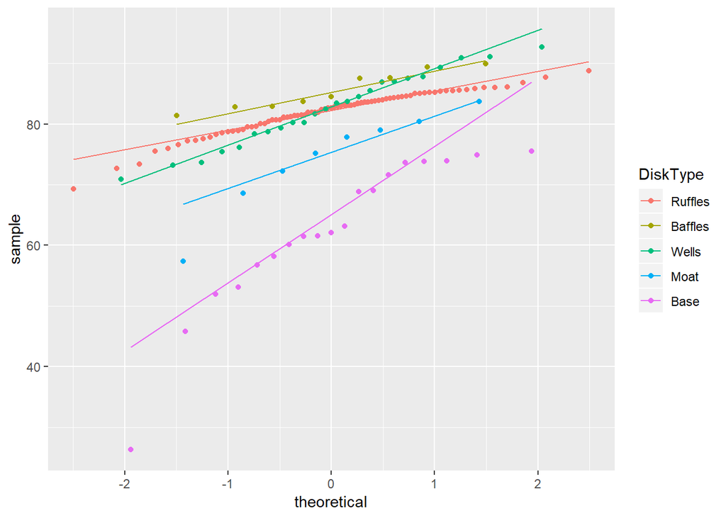

```r
ggplot(temp,aes(sample=PlasmaRecovery,color=DiskType))+stat_qq()+stat_qq_line()
```

```r
contrasts(temp$DiskType) <- contr.treatment(n=5,base=5)
base.aov <- aov(PlasmaRecovery~DiskType,data=temp);summary(base.aov)
```

```
##              Df Sum Sq Mean Sq F value Pr(>F)
## DiskType      4   6923    1731   45.55 <2e-16 ***
## Residuals   134   5091      38
## ---
## Signif. codes:  0 '***' 0.001 '**' 0.01 '*' 0.05 '.' 0.1 ' ' 1
```

```r
summary(glht(base.aov))
```

```
##
##   Simultaneous Tests for General Linear Hypotheses
##
## Fit: aov(formula = PlasmaRecovery ~ DiskType, data = temp)
##
## Linear Hypotheses:
##                  Estimate Std. Error t value Pr(>|t|)
## (Intercept) == 0   62.192      1.414  43.979  < 1e-05 ***
## DiskType1 == 0     19.783      1.575  12.560  < 1e-05 ***
## DiskType2 == 0     23.322      2.494   9.350  < 1e-05 ***
## DiskType3 == 0     20.337      1.893  10.744  < 1e-05 ***
## DiskType4 == 0     12.083      2.598   4.651 2.55e-05 ***
## ---
## Signif. codes:  0 '***' 0.001 '**' 0.01 '*' 0.05 '.' 0.1 ' ' 1
## (Adjusted p values reported -- single-step method)
```

dig through to find Masha plasma recovery # Effect of Hematocrit and trough volume

```r
RealVol <- function(x){
       if (x==3){return(x*0.8)}
  else if (x==4){return(x*0.9)}
  else if (x==5){return(x*0.8)}
  else {print('failed')}}

spins$Trough.Volume.real <- RealVol(spins$Trough.Volume)
```

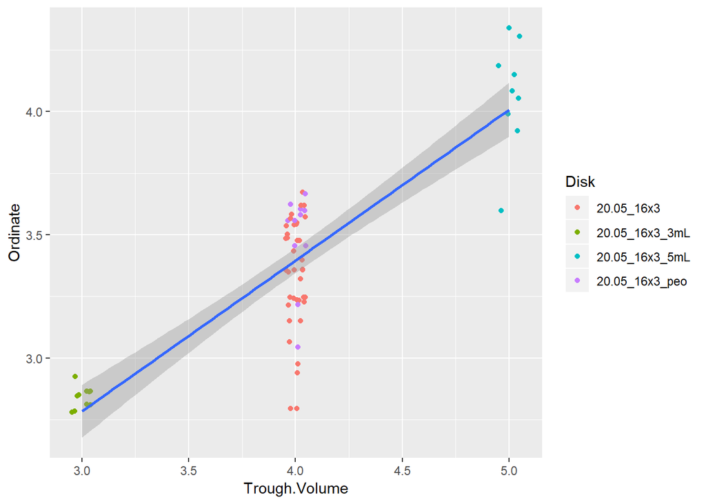

```r
spins$Vol_RBC2Trough <- with(spins,{((HCT*VolWB)/0.85-Trough.Volume)})
spins$HCT_Disk_calc <- with(spins,{(HCT*VolWB-HCT_plas*(VFlowdown))/Trough.Volume})
spins$Ordinate <- with(spins,{HCT*VolWB-HCT_plas*VFlowdown})
spins$Vol_Plasma2Trough <- with(spins,{VolWB*(1-HCT/0.8)-Trough.Volume})

ruffles <- spins %>% filter(.,grepl('16x3',Disk)) %>% droplevels()

ggplot(ruffles,aes(Trough.Volume,Ordinate))+
  geom_jitter(aes(color=Disk),width=0.05)+
  geom_smooth(method='lm',se=TRUE)
```

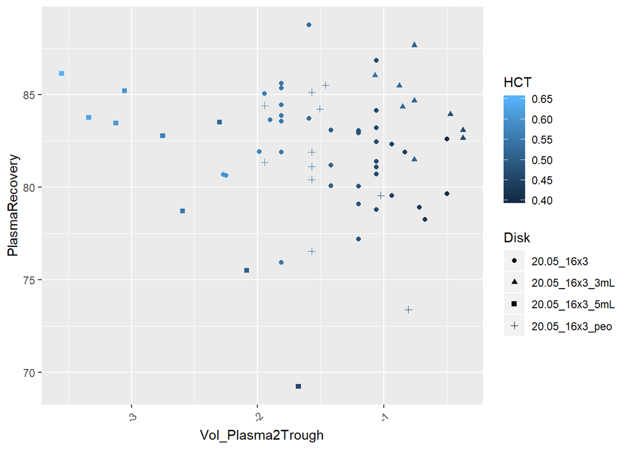

```r
ggplot(ruffles,aes(Vol_Plasma2Trough,PlasmaRecovery))+
  geom_point(aes(color=HCT,shape=Disk))+
  theme(axis.text.x = element_text(angle=45,hjust=1))
```

```r
rufflesum <- ruffles %>%
  dplyr::select(.,HCT_Disk_calc,HCT,Disk) %>%
  na.omit() %>%
  group_by(Disk) %>%
  summarise(n=n(),
           Hmin = min(HCT_Disk_calc),
           Hmean = mean(HCT_Disk_calc),
           Hmax = max(HCT_Disk_calc),
           SD = sd(HCT_Disk_calc),
           SE = SD/sqrt(n))
rufflesum
```

```
## # A tibble: 4 x 7
##   Disk               n  Hmin Hmean  Hmax     SD      SE
##   <fct>          <int> <dbl> <dbl> <dbl>  <dbl>   <dbl>
## 1 20.05_16x3        38 0.699 0.835 0.918 0.0556 0.00903
## 2 20.05_16x3_3mL    10 0.927 0.947 0.975 0.0146 0.00462
## 3 20.05_16x3_5mL     9 0.719 0.814 0.868 0.0447 0.0149
## 4 20.05_16x3_peo    11 0.761 0.872 0.916 0.0478 0.0144
```

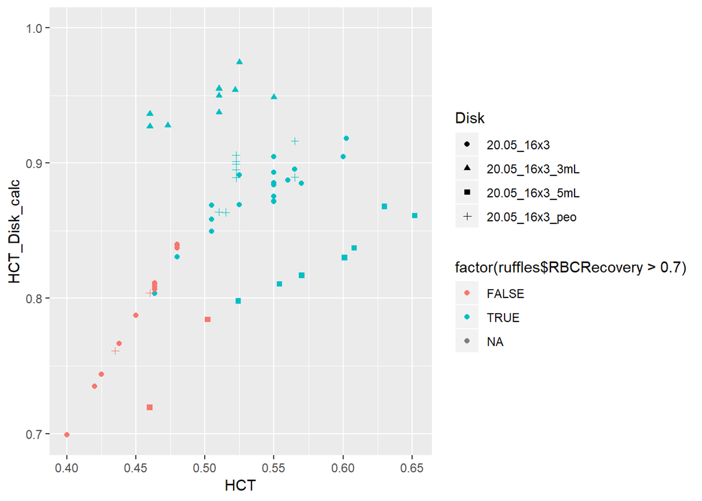

```r
ggplot(ruffles,aes(HCT,HCT_Disk_calc,color=factor(ruffles$RBCRecovery>0.7),shape=Disk))+
  geom_point()+
  ylim(NA,1)
```

```r
trough <- filter(ruffles,Disk != '20.05_16x3_peo')
```

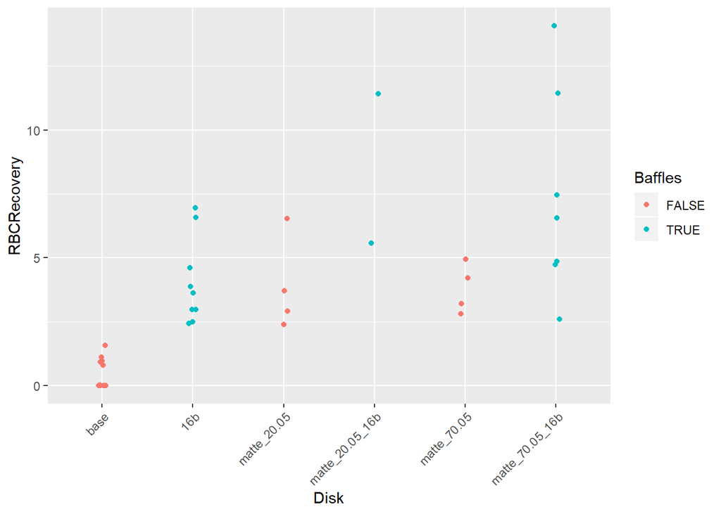

```r
baf4RR <- spins %>%
  filter(Disk %in% c('base','16b','matte_20.05','matte_20.05_16b','matte_70.05','matte_70.05_16b')) %>%
  # filter(Disk %in% c('matte_70.05','matte_70.05_16b')) %>%
  dplyr::select(c(Disk,HCT,RBCRecovery,Baffles)) %>%
  droplevels() %>%
  na.omit()

baf4RR$Disk <- factor(baf4RR$Disk,levels=c('base','16b','matte_20.05','matte_20.05_16b','matte_70.05','matte_70.05_16b'))
ggplot(baf4RR,aes(x=Disk,y=RBCRecovery,color=Baffles))+geom_jitter(width=0.05)+Disk_axis_theme
```

```r
wilcox.test(RBCRecovery ~ Baffles,data=baf4RR)
```

```
##
##  Wilcoxon rank sum test with continuity correction
##
## data:  RBCRecovery by Baffles
## W = 45, p-value = 5.031e-05
## alternative hypothesis: true location shift is not equal to 0
```

```r
nrow(baf4RR)
```

```
## [1] 39
```

Matte: 70: p=0.1636 n=11 20: p=0.2667 n=6 base: p= 8.29e-5 n=22

```r
bloody <- filter(trough,RBCRecovery>0.75) %>% droplevels(.$Disk)
bloody.lm <- lm(HCT*100 ~ Disk/RBCRecovery-1,data=bloody)
summary(bloody.lm)
```

```
##
## Call:
## lm(formula = HCT * 100 ~ Disk/RBCRecovery - 1, data = bloody)
##
## Residuals:
##      Min       1Q   Median       3Q      Max
## -2.28619 -0.68419 -0.02871  0.33097  2.06995
##
## Coefficients:
##                                Estimate Std. Error t value Pr(>|t|)
## Disk20.05_16x3                 47.80252    0.47632 100.359  < 2e-16 ***
## Disk20.05_16x3_3mL             44.92251    0.69091  65.020  < 2e-16 ***
## Disk20.05_16x3_5mL             49.18820    0.99699  49.337  < 2e-16 ***
## Disk20.05_16x3:RBCRecovery      0.88260    0.05976  14.770 2.64e-15 ***
## Disk20.05_16x3_3mL:RBCRecovery  0.63970    0.07320   8.739 9.58e-10 ***
## Disk20.05_16x3_5mL:RBCRecovery  1.01550    0.09435  10.763 8.04e-12 ***
## ---
## Signif. codes:  0 '***' 0.001 '**' 0.01 '*' 0.05 '.' 0.1 ' ' 1
##
## Residual standard error: 0.9933 on 30 degrees of freedom
## Multiple R-squared:  0.9997, Adjusted R-squared:  0.9997
## F-statistic: 1.783e+04 on 6 and 30 DF,  p-value: < 2.2e-16
```

```r
contrasts(bloody$Disk) <- contr.treatment(n=3,base = 2)
bloody.lm <- lm(100*HCT~RBCRecovery*Disk,data=bloody)
summary(bloody.lm)
```

```
##
## Call:
## lm(formula = 100 * HCT ~ RBCRecovery * Disk, data = bloody)
##
## Residuals:
##      Min       1Q   Median       3Q      Max
## -2.28619 -0.68419 -0.02871  0.33097  2.06995
##
## Coefficients:
##                   Estimate Std. Error t value Pr(>|t|)
## (Intercept)        44.9225     0.6909  65.020  < 2e-16 ***
## RBCRecovery         0.6397     0.0732   8.739 9.58e-10 ***
## Disk1               2.8800     0.8392   3.432  0.00177 **
## Disk3               4.2657     1.2130   3.517  0.00141 **
## RBCRecovery:Disk1   0.2429     0.0945   2.570  0.01536 *
## RBCRecovery:Disk3   0.3758     0.1194   3.147  0.00371 **
## ---
## Signif. codes:  0 '***' 0.001 '**' 0.01 '*' 0.05 '.' 0.1 ' ' 1
##
## Residual standard error: 0.9933 on 30 degrees of freedom
## Multiple R-squared:  0.9608, Adjusted R-squared:  0.9543
## F-statistic: 147.1 on 5 and 30 DF,  p-value: < 2.2e-16
```

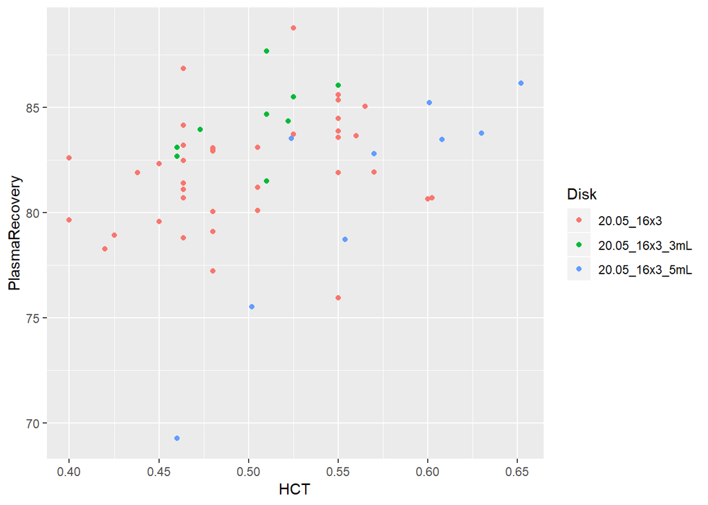

```r
newdata = with(trough,
               data.frame(RBCRecovery = RBCRecovery,
                          Disk = Disk))

trough$HCT_pred <- predict.lm(bloody.lm,newdata)

ggplot(trough,aes(HCT,PlasmaRecovery,color=Disk))+
  geom_point(na.rm=TRUE)
```

```r
  geom_line(aes(HCT_pred/100,RBCRecovery,color=Disk))
```

```
## mapping: x = ~HCT_pred/100, y = ~RBCRecovery, colour = ~Disk
## geom_line: na.rm = FALSE
## stat_identity: na.rm = FALSE
## position_identity
```

The threshold ratio of Red cells to trough volume is not constant for the different trough volumes. I think that the 5mL tubes maybe relax more as the cells descend.

No correlation between “trough volume” and plasma recovery. Adding the volume of stuck flowdown doesn’t change the disk hematocrit hardly at all.

### Comparison of Trough hematocrit calculation to experimental

The calcuated “Trough hematocrits” for 2 experiments on 20.05_16x3_5mL was 78.4376016, 83.7315333, and the measured values were 83 and 87. The calculated values are lower probably because it considers the whole disk as the trough; in reality, the red cells are more concentrated in the trough than in the flowdown region.

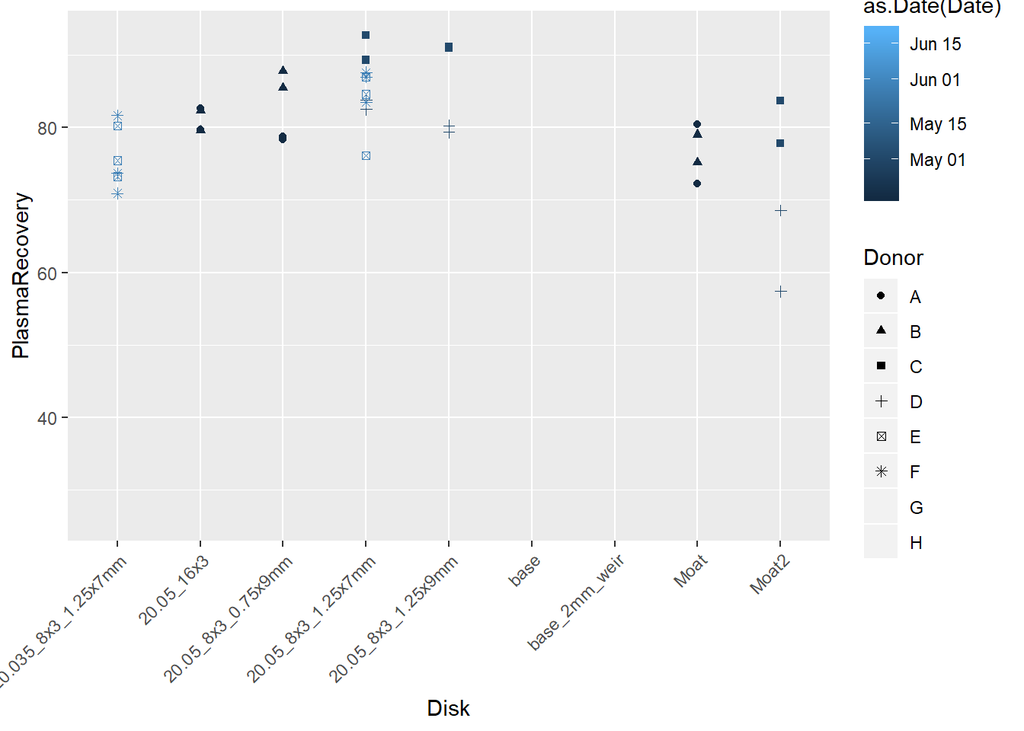

```r
roundpool <- spins[as.Date(spins$Date)>='2019-04-16',] # these experiments most happened over two days.  Select just two
# look at contrasts - use helmert and drop extra disk factor levels
ggplot(roundpool,aes(Disk,PlasmaRecovery,color=as.Date(Date),shape=Donor))+geom_point()+theme(axis.text.x = element_text(angle = 45, hjust=1))
```

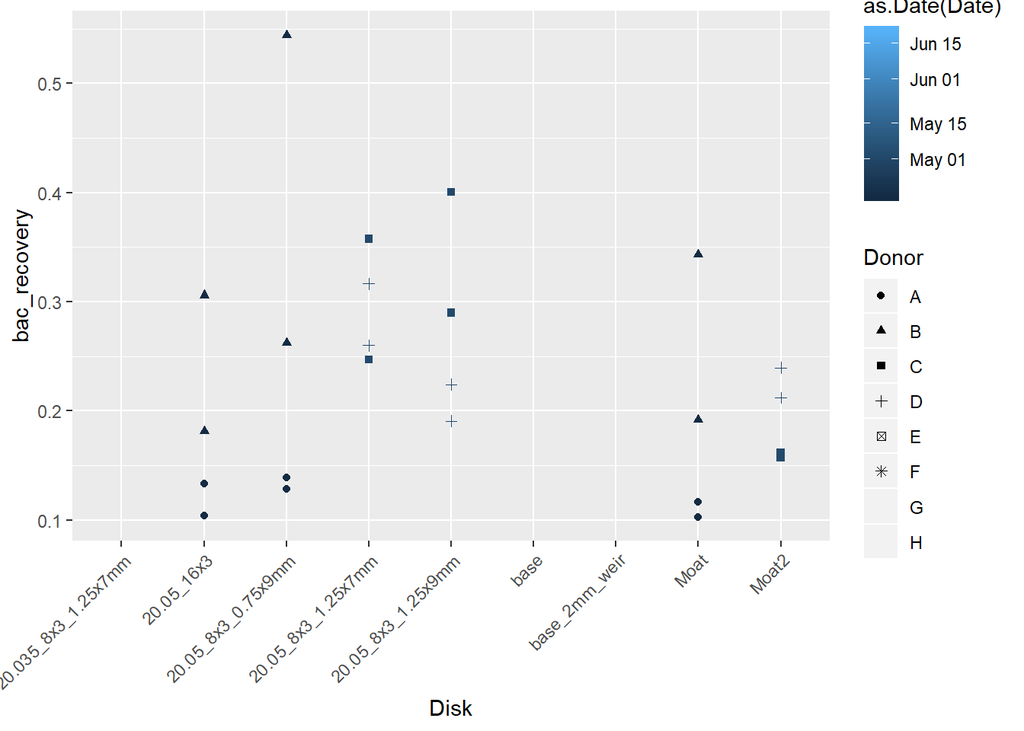

```r
ggplot(roundpool,aes(Disk,bac_recovery,  color=as.Date(Date),shape=Donor))+geom_point()+theme(axis.text.x = element_text(angle = 45, hjust=1))
```

```r
roundpool$Disk <- droplevels(roundpool$Disk)
contrasts(roundpool$Disk) <- 'contr.sum'
summary(lm(bac_recovery~Disk+Donor,data=roundpool))
```

```
##
## Call:
## lm(formula = bac_recovery ~ Disk + Donor, data = roundpool)
##
## Residuals:
##       Min        1Q    Median        3Q       Max
## -0.098363 -0.048487  0.002807  0.037618  0.183779
##
## Coefficients: (1 not defined because of singularities)
##                        Estimate Std. Error t value Pr(>|t|)
## (Intercept)            0.089042   0.047215   1.886  0.07760 .
## Disk20.05_8x3_0.75x9mm 0.087347   0.057826   1.511  0.15041
## Disk20.05_8x3_1.25x7mm 0.192101   0.066772   2.877  0.01095 *
## Disk20.05_8x3_1.25x9mm 0.173069   0.066772   2.592  0.01966 *
## DiskMoat               0.007354   0.057826   0.127  0.90038
## DiskMoat2              0.089248   0.066772   1.337  0.20005
## DonorB                 0.184284   0.047215   3.903  0.00127 **
## DonorC                 0.028416   0.047215   0.602  0.55571
## DonorD                       NA         NA      NA       NA
## ---
## Signif. codes:  0 '***' 0.001 '**' 0.01 '*' 0.05 '.' 0.1 ' ' 1
##
## Residual standard error: 0.08178 on 16 degrees of freedom
##   (24 observations deleted due to missingness)
## Multiple R-squared:  0.5956, Adjusted R-squared:  0.4187
## F-statistic: 3.367 on 7 and 16 DF,  p-value: 0.02101
```

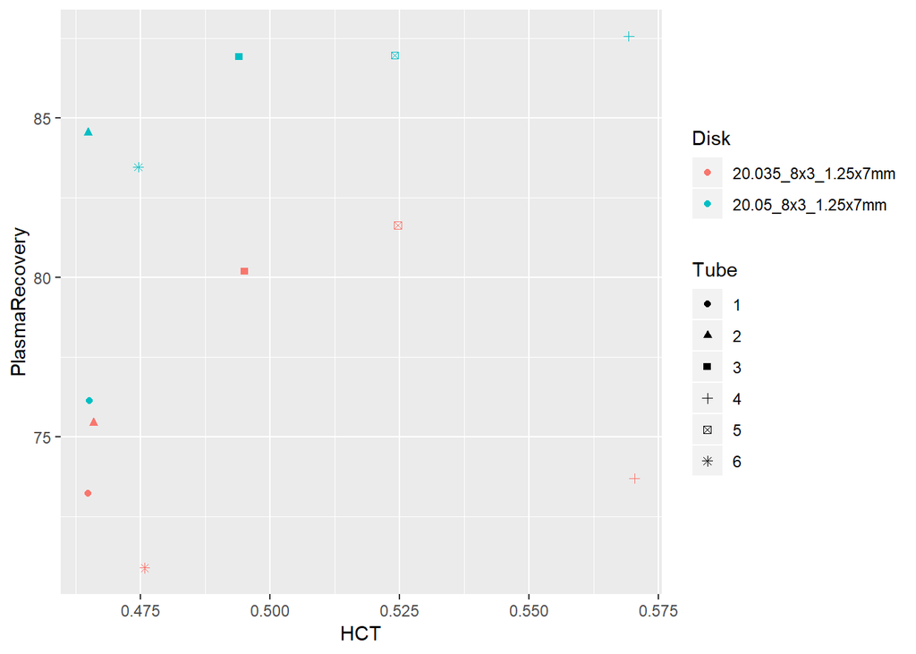

```r
rufdep <- spins %>% filter(Date=='2019-5-29') %>% dplyr::select(.,1:7,11,12,'RBCRecovery','PlasmaRecovery') # |Disk=='base_2mm_weir'
rufdep$Tube <- gl(6,2) #rep(1:6,each=2)
ggplot(rufdep,aes(HCT,PlasmaRecovery,color=Disk,shape=Tube))+geom_jitter(width=0.001)
```

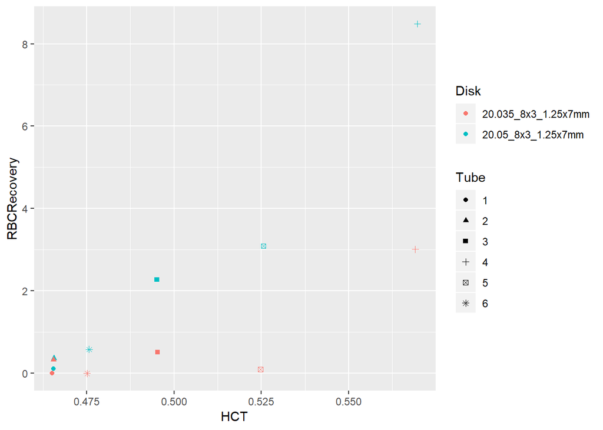

```r
ggplot(rufdep,aes(HCT,RBCRecovery,color=Disk,shape=Tube))+geom_jitter(width=0.001)
```

```r
wilcox.test(PlasmaRecovery~Disk,paired=T,data=rufdep)
```

```
##
##  Wilcoxon signed rank test
##
## data:  PlasmaRecovery by Disk
## V = 0, p-value = 0.03125
## alternative hypothesis: true location shift is not equal to 0
```

The HCT threshold seems to have changed some

```r
moat <- subset(spins,as.Date(Date)=='2019-4-16')
moataov <- lm(PlasmaRecovery~Disk+Donor,data=moat)
summary(moataov)
```

```
##
## Call:
## lm(formula = PlasmaRecovery ~ Disk + Donor, data = moat)
##
## Residuals:
##     Min      1Q  Median      3Q     Max
## -3.0056 -2.8010 -0.0467  1.8482  5.1410
##
## Coefficients:
##                        Estimate Std. Error t value Pr(>|t|)
## (Intercept)              79.594      1.964  40.535 1.51e-10 ***
## Disk20.05_8x3_0.75x9mm    1.534      2.405   0.638    0.541
## DiskMoat                 -4.339      2.405  -1.804    0.109
## DonorB                    2.881      1.964   1.467    0.180
## ---
## Signif. codes:  0 '***' 0.001 '**' 0.01 '*' 0.05 '.' 0.1 ' ' 1
##
## Residual standard error: 3.401 on 8 degrees of freedom
## Multiple R-squared:  0.5172, Adjusted R-squared:  0.3362
## F-statistic: 2.857 on 3 and 8 DF,  p-value: 0.1045
```

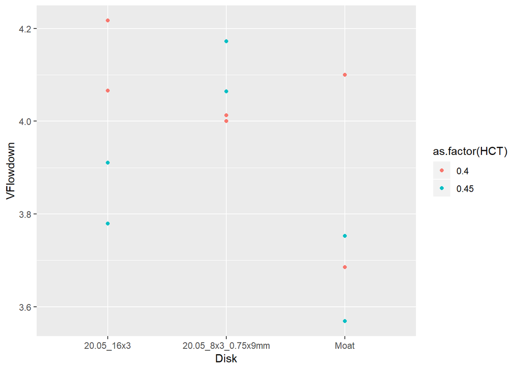

```r
ggplot(moat,aes(Disk,VFlowdown,color=as.factor(HCT)))+geom_point()
```

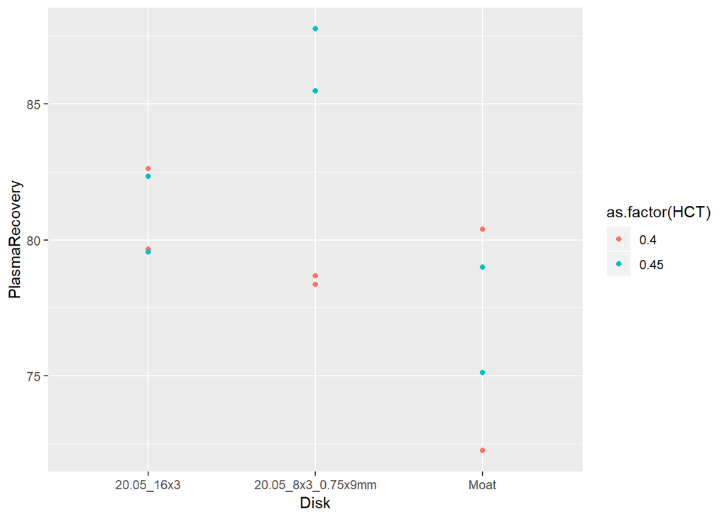

```r
ggplot(moat,aes(Disk,PlasmaRecovery,color=as.factor(HCT)))+geom_point()
```

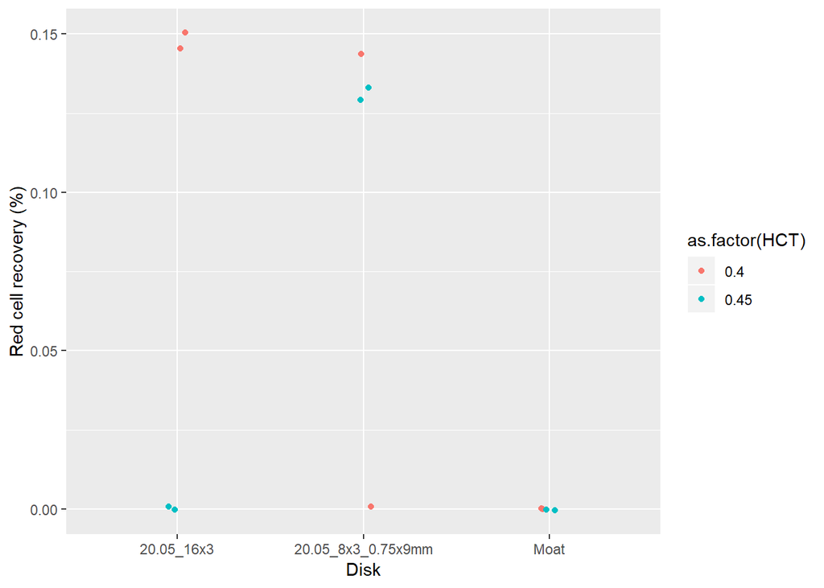

```r
ggplot(moat,aes(Disk,RBCRecovery,color=as.factor(HCT)))+geom_jitter(width=0.05)+ylab('Red cell recovery (%)')
```

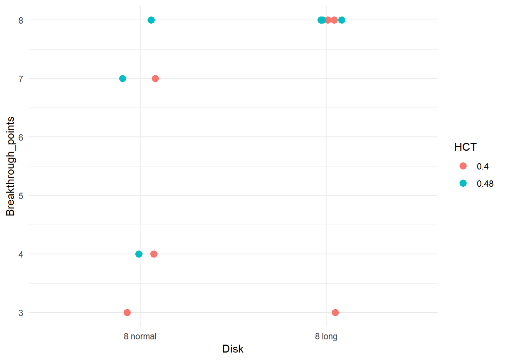

```r
ruffles8 <- spins %>% filter(as.Date(Date)==as.Date('2019-4-9')) %>%
                             dplyr::select(.,Disk,HCT,HCT_plas,PlasmaRecovery,VFlowdown)
ruffles8$Donor <- c(1,1,1,1,1,1,2,2,2,2,2)

short = c(7,3,4,7,8,4)
long = c(8,8,8,8,3,8)
donor = c(1,2,1,2,1,2,2,1,2,1,2,1)
HCT = c(0.48,0.40,0.48,0.40,0.48,0.40,0.40,0.48,0.40,0.48,0.40,0.48)
channels <- data.frame(Disk=gl(2,6,labels=c('8 normal','8 long')),
                       Breakthrough_points=c(short,long),
                       Donor=as.character(donor),
                       HCT = factor(HCT))

ggplot(channels,aes(Disk,Breakthrough_points,color=HCT))+
  geom_jitter(width=0.1,height=0.,size=3)+
  theme_minimal()
```

```r
ruffsum <- ruffles8 %>% group_by(Disk,Donor) %>% summarise(n=n(),SD=sd(VFlowdown))
with(ruffsum,(n-1)*SD)
```

```
## [1] 0.02010506 0.29697858 0.08707252 0.04480701
```